# Statistical Analysis: Weather and Temporal Effects on NYC Citi Bike Ride Duration

# Model Diagnostics

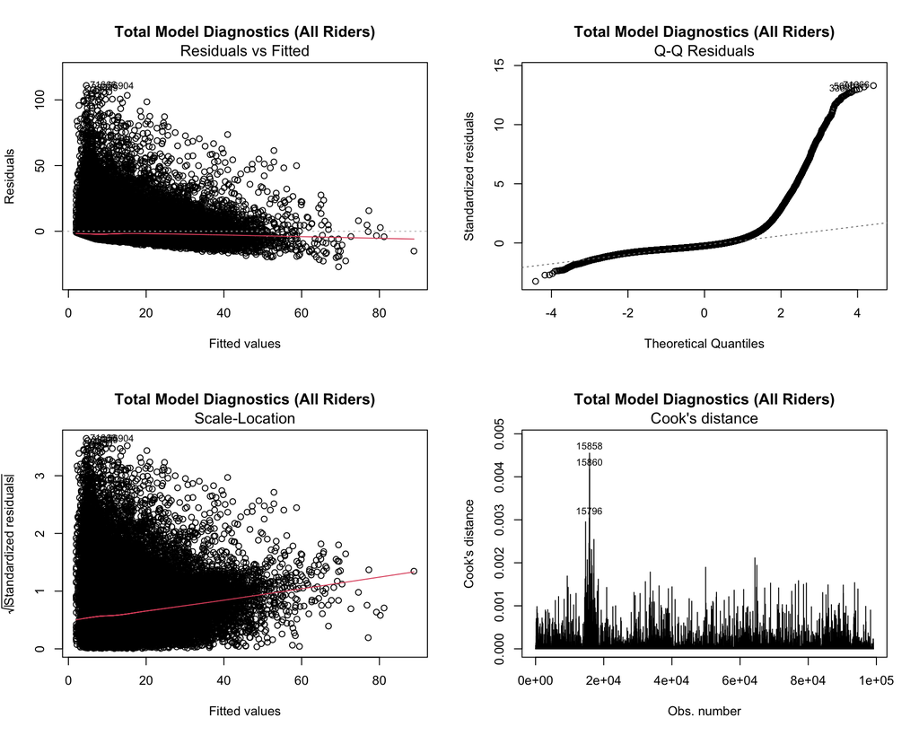

```r
# Diagnostic plots for total model (sample 5000 for speed)
par(mfrow = c(2, 2))
plot(model_total_full, which = 1:4, main = "Total Model Diagnostics (All Riders)")
```

# Discussion and Conclusions

## Main Findings Summary

- Casual riders: ~51% longer trips
- Members: Quick utilitarian trips (commuting)
- Casual: Leisurely recreational trips (tourism/leisure)

### 4. **Superior Statistical Power**

Analyzing 100,000 rides vs 30 daily observations provides: - Much smaller standard errors - Ability to detect small effects - High confidence in all findings

## Comparison: Ridership vs Duration Analysis

| Aspect | Daily Ridership (N=30) | Individual Duration (N=100,000) |
| --- | --- | --- |
| **Sample Size** | 30 days | ~100,000 rides |
| **Statistical Power** | Low | Very High |
| **What It Measures** | How many people ride | How long each ride lasts |
| **Main Finding** | Weather strongly affects WHETHER people ride | Distance strongly affects HOW LONG they ride |
| **Confidence** | Moderate | Very High |

## Why Both Analyses Matter

**Daily Ridership Analysis** answers: “What makes people decide to ride?” - Weather is VERY important (rain = -27% ridership) - Day of week matters (commuter patterns)

**Ride Duration Analysis** answers: “Once someone decides to ride, what affects their trip?” - Distance is most important - Weather has small effects on duration - User type drives duration differences

## Practical Implications

1. **For Operations**: Focus rebalancing on distance patterns, not just weather
2. **For Marketing**: Emphasize quick trips for members, leisurely rides for casual
3. **For Urban Planning**: Distance/destination matters more than weather for trip planning

## Limitations

1. Still cross-sectional (one month of data)
2. Ride duration may have non-linear relationships
3. Unmeasured factors: terrain, bike type, rider fitness
4. Outliers removed (rides > 2 hours)